### Homework 3

# Solution Sample

## Part 1: Singular Values/Vectors and Eigenvalues/Vectors

### Problem 1.1 (ES)

Find exact expressions (as opposed to approximate numerical values) for the eigenvalues $\lambda_1$, $\lambda_2$ and corresponding *unit-norm* eigenvectors $\mathbf{e}_1$, $\mathbf{e}_2$ of the matrix

$$ C = \left[\begin{array}{rr} 0 & 1\\-2 & -2\end{array}\right] $$

Use the symbol $i$ for the imaginary unit, if needed. When normalizing, recall that the squared norm of a complex vector $\mathbf{a}$ is the inned product of the vector with itself, that is, $\mathbf{a}^{\ast}\mathbf{a}$, where $\mathbf{a}^{\ast}$ is the transpose and conjugate of $\mathbf{a}$.

No need to show your derivation, unless you want partial credit should your answer be wrong.

### Answer

The derivation is shown here for pedagogical reasons, and is not necessary for full credit. The characteristic polynomial of $C$ is $$ \det(C - \lambda I) = -\lambda(-2-\lambda) + 2 = \lambda^2 + 2\lambda + 2 = (\lambda + 1)^2 + 1 $$ and this expression is zero when $$ \lambda + 1 = \pm i $$ that is, for $$ \lambda_{1,2} = -1 \pm i\;. $$ The eigenvector $\mathbf{e}_1$ corresponding to $\lambda_1 = -1 + i$ can be found by solving the system $$ (C - \lambda_1 I)\ \mathbf{e} = \left[\begin{array}{cc}1 - i & 1\\ - 2 & -1-i \end{array}\right] = \left[\begin{array}{c}0\\0 \end{array}\right] \;. $$ The two equations in this system are linearly dependent by construction, so all we need to find is a vector orthogonal to, say, the first row of the matrix. This is easily done by inspection to yield $$ \mathbf{e}_1 \propto \left[\begin{array}{c}-1-i \\2\end{array}\right] $$ and the norm of the right-hand side is $\sqrt{6}$. A similar line of reasoning yields $\mathbf{e}_2$, and in conclusion

\begin{eqnarray*} \lambda_1 = -1 + i &\;\;\;\text{,}\;\;\;& \mathbf{e}_1 = \frac{1}{\sqrt{6}}\left[\begin{array}{c}-1-i \\2\end{array}\right] \\ \mbox{}\\ \lambda_2 = -1 - i &\text{,}& \mathbf{e}_2 = \frac{1}{\sqrt{6}}\left[\begin{array}{c}-1+i \\2\end{array}\right] \\ \end{eqnarray*}

### Problem 1.2

Find approximate numerical expressions, to four decimal digits after the period, for the left singular vectors $\mathbf{u}_1$, $\mathbf{u}_2$, singular values $\sigma_1$, $\sigma_2$, and right singular vectors $\mathbf{v}_1$, $\mathbf{v}_2$ of the matrix $C$ in Problem 1.1.

### Answer

\begin{eqnarray*} \mathbf{u}_1 &=& \left[\begin{array}{c} -0.2567 \\ 0.9665 \end{array}\right] \\ \mbox{} \\ \mathbf{u}_2 &=& \left[\begin{array}{c} 0.9665 \\ 0.2567 \end{array}\right] \\ \mbox{} \\ \sigma_1 &=& 2.9208 \\ \sigma_2 &=& 0.6847 \\ \mbox{} \\ \mathbf{v}_1 &=& \left[\begin{array}{c} -0.6618 \\ -0.7497 \end{array}\right] \\ \mbox{} \\ \mathbf{v}_2 &=& \left[\begin{array}{c} -0.7497 \\ 0.6618 \end{array}\right] \end{eqnarray*}

### Problem 1.3 (ES)

Use the equation that defines eigenvalues $\lambda$ and eigenvectors $\mathbf{e}$ of a square matrix $A$ to show that if $A$ is symmetric and real then its eigenvalues are real, and its eigenvectors can be scaled to be real.

Hint: Write the equation and its Hermitian (*i.e.*, its transpose-conjugate): \begin{eqnarray*} A \mathbf{e} &=& \lambda \mathbf{e} \\ \mathbf{e}^{\ast} A^T &=& \lambda^{\ast} \mathbf{e}^{\ast} \end{eqnarray*} Then multiply the first by $\mathbf{e}^{\ast}$ from the left and the second by $\mathbf{e}$ from the right, and reason from there. Justify all your steps.

### Answer

From \begin{eqnarray*} A \mathbf{e} &=& \lambda \mathbf{e} \\ \mathbf{e}^{\ast} A^T &=& \lambda^{\ast} \mathbf{e}^{\ast} \end{eqnarray*} we obtain \begin{eqnarray*} \mathbf{e}^{\ast} A \mathbf{e} &=& \lambda \mathbf{e}^{\ast} \mathbf{e} \\ \mathbf{e}^{\ast} A^T \mathbf{e} &=& \lambda^{\ast} \mathbf{e}^{\ast} \mathbf{e} \end{eqnarray*} that is, using also the symmetry of $A$, \begin{eqnarray*} \mathbf{e}^{\ast} A \mathbf{e} &=& \lambda \|\mathbf{e}\|^2 \\ \mathbf{e}^{\ast} A \mathbf{e} &=& \lambda^{\ast} \|\mathbf{e}\|^2 \;. \end{eqnarray*} Since the left-hand sides are identical, we have $$ \lambda \|\mathbf{e}\|^2 \;=\; \lambda^{\ast} \|\mathbf{e}\|^2 $$ where the real number $\|\mathbf{e}\|^2$ is nonzero by definition of eigenvector. We can therefore divide by that number to obtain $$ \lambda \;=\; \lambda^{\ast} \;\;\;\text{that is,}\;\;\; \lambda\in\mathbb{R}\;. $$

Finally, the eigenvectors are solutions of $$ (A - \lambda I)\ \mathbf{e} = \mathbf{0}\;, $$ and we just showed that the matrix on the left-hand side is real. This matrix is degenerate when $\lambda$ is equal to one of the ergenvalues, and therefore has a nontrivial null space in $\mathbb{R}^n$, where $n$ is the number of rows and columns of $A$. Thus, it is possible to choose a real-valued vector $\mathbf{e}$ that solves this system.

### Problem 1.4 (ES)

Refer to the geometric meaning of the SVD to argue that the SVD of a tame matrix $A$ is unique up to appropriate substitutions of $U$ and $V$ with siblings of each. Be detailed and accurate in your reasoning, and specify all appropriate sibling substitutions. That is, if $$ A \;=\; [\mathbf{u}_1,\ \mathbf{u}_2]\ \Sigma\ [\mathbf{v}_1,\ \mathbf{v}_2]^T $$ is an SVD of a tame matrix $A$, what are all the other SVDs of $A$?

[Note: If $A$ were not tame, then its SVD would not necessarily be unique up to sibling substitutions of $U$ and $V$. Make sure you explain what it is that makes tame matrices special in this regard.]

### Answer

The rowspace of a tame matrix $A$ is $\mathbb{R}^2$, and the unit hypersphere in it is the unit circle. The matrix $A$ maps this circle to a (unique) ellipse in the range $\mathbb{R}^2$, and since the singular values of a tame matrix are different from each other, the minor and major axis of the ellipse are uniquely determined. Therefore, $\mathbf{u}_1$ and $\mathbf{u}_2$ are uniquely defined up to signs, and the vectors $\mathbf{v}_1$ and $\mathbf{v}_2$ that map into $\mathbf{u}_1$ and $\mathbf{u}_2$ are uniquely defined once $\mathbf{u}_1$ and $\mathbf{u}_2$ are given, because a tame matrix is invertible (since its rank is 2, having all-nonzero singular values). The singular values are equal to the half-lengths of the axes of the ellipse, and are therefore unique.

### Problem 1.5 (ES)

Show that if $A = U\Sigma V^T$ is the SVD of a symmetric, tame matrix $A$, then $U$ and $V$ are siblings of each other.

[Hint: Write the transpose of $A = U\Sigma V^T$ and reason from there, using results proven in previous problems.]

### Answer

The transpose of $A = U\Sigma V^T$ is $A^T = V\Sigma^T U^T$. Since $A$ is symmetric and $\Sigma$ is diagonal (and therefore symmetric as well), this yields $A = V\Sigma U^T$. The right-hand side of this expression has the format of an SVD. Since $A$ is tame, its SVD is unique up to sibling substitutions of its left and right orthogonal matrices (Problem 1.4), and therefore $V\Sigma U^T$ and $U\Sigma V^T$ are the same SVD of $A$, up to sibling substitutions. It follows that $U$ and $V$ are siblings of each other.

### Problem 1.6 (ES)

Show that the singular values of a symmetric, tame matrix $A$ are the absolute values of its eigenvalues; the left singular vectors (columns of $U$) are its eigenvectors (up to a nonzero scale factor); and the matrix $V$ of right singular vectors is a sibling of $U$.

[Hint: Write the two equations $A\mathbf{e}_1 = \lambda_1 \mathbf{e}_1$ and $A\mathbf{e}_2 = \lambda_2 \mathbf{e}_2$ together as a single matrix equation $A E = E \Lambda$, where

$$ \Lambda = \left[\begin{array}{cc}\lambda_1 & 0\\0 & \lambda_2 \end{array}\right] $$

and reason from there, using results proven so far. Warning: Eigenvalues, even when real, can be negative.]

### Answer

From problem 1.3 and Fact 1, we see that a tame symmetric matrix has real eigenvalues, and that the matrix $E = [\mathbf{e}_1,\ \mathbf{e}_2]$ of its (unit-norm) eigenvectors is orthogonal. If we write $A\mathbf{e}_1 = \lambda_1 \mathbf{e}_1$ and $A\mathbf{e}_2 = \lambda_2 \mathbf{e}_2$ as $A E = E \Lambda$, we can then multiply from the right by $E^T$ to obtain $$ A = E\Lambda E^T\;. $$ This equation is nearly in the format of an SVD, if the eigenvalues are sorted so that $\lambda_1 > \lambda_2$, except that either eigenvalue could be negative. Let then $$ \sigma_i = s_i \lambda_i = |\lambda_i| \;\;\;\text{for}\;\;\; i = 1, 2 $$ and where $s_i$ is the sign of $\lambda_i$. The matrix $$ V = [s_1\mathbf{e}_1,\ s_2\mathbf{e}_2] $$ is still orthogonal, and if we let $U = E$ we can rewrite $A = E\Lambda E^T$ as follows: $$ A = U\Sigma V^T $$ where $\Sigma$ has $\sigma_1$ and $\sigma_2$ on its diagonal. This expression is in the format of an SVD. Since a tame matrix has a unique SVD up to sibling substitutions, this is a valid SVD of $A$. By construction,

- $\sigma_i = |\lambda_i|$
- $U = E$
- $U$ and $V$ are siblings

as promised.

### Problem 1.7 (ES)

Show that the left and right singular vectors of a tame, symmetric, and positive definite matrix $A$ are its (unit-norm) eigenvectors, and its singular values are its eigenvalues.

[Hint: Given problem 1.6, this is immediate.]

### Answer

The eigenvalues of a positive definite matrix are positive, so that, from problem 1.6, we obtain $\Sigma = \Lambda$ and $U = V = E$, as long as the eigenvalues are named so that $\lambda_1 > \lambda_2$.

### Problem 1.8 (ES)

Show that if $A$ is any real $n\times 2$ matrix with singular values $\sigma_1 > \sigma_2 > 0$ and SVD $A = U\Sigma V^T$, and $S = A^T A$, then the eigenvalues of $S$ are $\sigma_1^2$ and $\sigma_2^2$, and the corresponding eigenvectors are the columns of $V$.

[Hint: Write $S$ in terms of $U$, $\Sigma$, $V$ and recall that two eigenvalue equations,

$$ B \mathbf{x}_1 = \lambda_1 \mathbf{x}_1 \;\;\;\text{and}\;\;\; B \mathbf{x}_2 = \lambda_2 \mathbf{x}_2 $$

can be written in matrix form as

$$ B X = X \Lambda \;\;\;\text{where}\;\;\; X = [\mathbf{x}_1, \mathbf{x}_2] \;\;\;\text{and}\;\;\; \Lambda = \left[\begin{array}{cc}\lambda_1 & 0\\0 & \lambda_2 \end{array}\right]\;. $$

Tameness is not needed here.]

### Answer

The matrix $S$ can be written as follows:

$$ S = A^T A = V \Sigma^T U^T U\Sigma V^T = V \Sigma_2^2 V^T $$

where $\Sigma_2$ is the upper left $2\times 2$ block of $\Sigma$ and $V$ is $2\times 2$. This is the eigenvalue decomposition of $S$, because the equation above yields (upon multiplication by $V$ from the right)

$$ S V = V \Sigma_2^2 $$

that is,

$$ S\mathbf{v}_1 = \sigma_1^2 \mathbf{v}_1 \;\;\;\text{and}\;\;\; S\mathbf{v}_2 = \sigma_2^2 \mathbf{v}_2\;. $$

From the last two equations we read that the eigenvalues of $S$ are $\sigma_1^2$ and $\sigma_2^2$, and the corresponding eigenvectors are $\mathbf{v}_1$ and $\mathbf{v}_2$, the columns of $v$.

Incidentally, from this result it follows that $S$ is semidefinite positive, since its eigenvalues are nonnegative. This fact could also be derived directly from the definition of a semidefinite positive matrix: For any $m\times n$ matrix $A$ and nonzero vector $\mathbf{x}\in\mathbb{R}^n$ we can write

$$ \mathbf{x}^T S \mathbf{x} = \mathbf{x}^T A^T A \mathbf{x} = \|A\mathbf{x}\|^2 \geq 0\;. $$

## Part 2: Orthogonality of the Right Singular Vectors

Use calculus to prove that $\mathbf{v}_1$ and $\mathbf{v}_2$ as defined above are orthogonal to each other. This implies that the matrix $V$ in the SVD $A = U\Sigma V^T$ of any $n\times 2$ matrix $A$ is orthogonal.

### Answer

The two axes of the ellipse $A\mathbf{x}$ with $\|\mathbf{x}\|=1$ are given by the values $\pm\mathbf{v}_{1}, \pm\mathbf{v}_{2}$ of $\mathbf{x}$ on the unit circle that respectively maximize and minimize the norm of the vector $\mathbf{y} = A\mathbf{x}$, that is, by the values of $\theta$ that yield the stationary points of the function

$$ f(\theta) = \|A\left[\begin{array}{c}\cos\theta\\\sin\theta\end{array}\right]\|^{2}\;. $$

To find these stationary points, we can proceed in various ways, of which two are shown next.

#### Method 1:

$$ f(\theta) = \mathbf{x}^T AA^T\mathbf{x} = \left[\begin{array}{cc}\cos\theta & \sin\theta\end{array}\right] B \left[\begin{array}{c}{\cos\theta\\\sin\theta}\end{array}\right] $$ where $$ B = \left[\begin{array}{cc}a & b\\ b & d\end{array}\right] = A^{T}A $$ is a $2\times 2$ symmetric matrix, so that $$ f(\theta) = a \cos^2\theta + 2b \cos\theta\sin\theta + d \sin^2\theta = \frac{a}{2} [1 + \cos(2\theta)] + b \sin(2\theta) + \frac{d}{2} [1 - \cos(2\theta)]\;. $$ The last expression is a constant plus a linear combination of three sinusoids with the same argument $2\theta$, and can therefore be written as a constant plus a single sinusoid with argument $2\theta$ (and suitable phase): $$ f(\theta) = C + D \sin(2\theta + \phi) \;. $$ This function achieves its maxima and minima at intervals of $\pi/2$, that is, at orthogonal points on the unit circle, as claimed.

#### Method 2:

One can also find stationary points by taking the derivative of $f(\theta)$ and setting it to zero: $$ \frac{df(\theta)}{d\theta} = 2 \left[\begin{array}{cc}-\sin\theta &\cos\theta\end{array}\right] B\left[\begin{array}{c}\cos\theta\\\sin\theta\end{array}\right] = 0 $$ where $B$ is the same as in method 1. Writing out the matrix product yields \begin{eqnarray*} \frac{df(\theta)}{d\theta} &=& 2b(\cos^{2}\theta - \sin^{2}\theta) + 2(d-a)\sin\theta\cos\theta\\ &=& 2b \cos 2\theta + (d-a)\sin 2\theta\;, \end{eqnarray*} that is, \begin{equation} \frac{df(\theta)}{d\theta} = E\cos(2\theta-\phi)\label{deriv}\;. \end{equation}

Thus, the derivative of $f(\theta)$ is a sinusoid in $2\theta$, and therefore it crosses zero at intervals of $\pi/2$, that is, at orthogonal points on the unit circle, as claimed.

#### Note:

For either argument, the actual values of the constants are irrelevant. For completeness, here they are for the second argument: \begin{eqnarray*} E = \sqrt{(2b)^{2}+(d-a)^{2}} & \mbox{ and } & \phi = \arctan_{2}(d-a,2b)\;. \end{eqnarray*}

## Part 3: Haar Pyramids

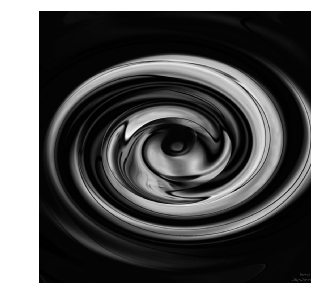

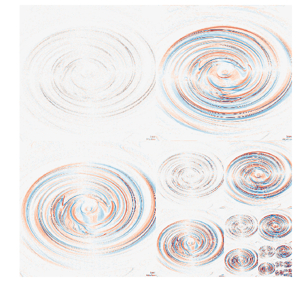

```python
import numpy as np
from skimage import io
from matplotlib import pyplot as plt
%matplotlib inline

def i2p(img):
    img = np.ndarray.astype(img, 'float')
    sz = img.shape
    depth = np.rint(np.log2(sz))[0].astype(int)
    assert np.all(2 ** depth == sz[:2]), 'Image must be square with 2^k rows'
    E = np.array([[1, -1, 1, -1], [1, 1, -1, -1],
                  [1, -1, -1, 1], [1, 1, 1, 1]]) / 4;
    detail = []
    for level in range(depth):
        Q = [img[::2, ::2], img[1::2, ::2], img[::2, 1::2], img[1::2, 1::2]]
        det = []
        for d in range(4):
            det.append(np.zeros_like(Q[0]))
            for q in range(4):
                det[d] += E[d, q] * Q[q]
        detail.append(det[:3])
        img = det[3]
    return detail, img

def composite(detail, mean):
    n = detail[0][0].shape[0]
    n2 = n * 2
    comp = np.full((n2, n2), mean[0, 0])
    a, b, c = 0, n, n2
    for d in detail:
        comp[a:b, b:c] = d[0]
        comp[b:c, a:b] = d[1]
        comp[a:b, a:b] = d[2]
        a, n = b, int(n/2)
        b += n
    return comp

def show(img, size=(5, 5), cmap='gray'):
    plt.figure(figsize=size)
    plt.imshow(img, cmap=cmap)
    plt.axis('off')
    plt.show()

img = io.imread('ripples.png')
show(img)

(detail, average) = i2p(img)

comp = composite(detail, average)
recolor = np.multiply(np.log(1 + np.abs(comp)), np.sign(comp))
show(recolor, (10, 10), 'RdBu')
```

### Problem 3.1

After carefully studying the code provided, and in particular how equation ($\ast$) is implemented in function `i2p`, implement a function with header

```
def p2i(detail, average):
```

that takes a bandpass pyramid `(detail,average)` produced by `i2p` and returns the original image at full resolution. Round the image at the end of the function `p2i` and cast it to `numpy.uint8`. For instance:

```
return numpy.round(img).astype(numpy.uint8)
```

Show your code and the reconstructed image, displayed with the provided function `show` called with the default keyword arguments.

### Answer

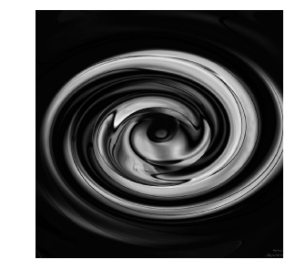

```python
def p2i(detail, average):
    F = np.array([[1, 1, 1, 1], [-1, 1, -1, 1],
                  [1, -1, -1, 1], [-1, -1, 1, 1]])
    img, n = average, average.shape[0]
    for det in reversed(detail):
        Q = [img.copy() for q in range(4)]
        for q in range(4):
            for d in range(3):
                Q[q] += F[q, d] * det[d]
        n *= 2
        img = np.zeros((n, n))
        img[::2, ::2] = Q[0]
        img[1::2, ::2] = Q[1]
        img[::2, 1::2] = Q[2]
        img[1::2, 1::2] = Q[3]
    return np.round(img).astype(np.uint8)

rebuilt = p2i(detail, average)

show(rebuilt)
```

## Part 4: Principal Component Analysis

### Problem 4.1

Use the function `scipy.linalg.eigh`, which computes eigenvalues and eigenvectors of a Hermitian matrix ("Hermitian" means symmetric if the matrix is real), to write a function with header

```
def pca(A, k):
```

that takes an $m\times n$ `numpy` array `A` of floats and an integer `k` and returns the triple `(mu, V, s)` defined as follows:

- `mu` is the mean of the rows of $A$
- `V` is the $n\times k$ matrix $V_k$ whose columns are the first $k$ right singular vectors of the centered version of $A$
- `s` is an $n$-dimensional vector with the standard deviations of $A$ along all principal axes, $s_i = \sigma_i / \sqrt{m-1}$ for $i=1,\ldots, n$ (not just the first $k$).

Show your code and the result of the tests given in the template.

### Answer

```python
import numpy as np
from scipy.linalg import eigh

def pca(A, k):
    mu = A.mean(axis=0)
    C = A - mu
    S = np.dot(np.transpose(C), C)
    lam, V = eigh(S)

    # Deal with numerical inaccuracy of eigh
    lam[lam < 0.0] = 0.0

    order = np.argsort(-lam)
    lam, V = lam[order], V[:, order]
    s = np.sqrt(lam / (C.shape[0] - 1))
    V = V[:, :k]
    return mu, V[:, :k], s
```

```python
try:
    import numpy as np
    A = np.array([[1, 0, -2, 3],
              [0, 2, 1, -1],
              [-3, 1, 0, -1],
              [0, 0, 1, 0],
              [-1, 1, -1, 0]]).astype(np.float64)

    np.set_printoptions(precision=3, suppress=True)
    for k in range(1, 4):
        (mu, VT, s) = pca(A, k)
        print('k =', k, end='\n\n')
        print('mu =', mu, end='\n\n')
        print('VT =', VT, sep='\n', end='\n\n')
        print('s =', s, end='\n\n')
        print(30 * '=')

except NameError:
    pass
```

```
k = 1

mu = [-0.6  0.8 -0.2  0.2]

VT =
[[ 0.498]
 [-0.238]
 [-0.433]
 [ 0.713]]

s = [2.281 1.282 0.717 0.2  ]

==============================
k = 2

mu = [-0.6  0.8 -0.2  0.2]

VT =
[[ 0.498  0.774]
 [-0.238  0.1  ]
 [-0.433  0.611]
 [ 0.713 -0.135]]

s = [2.281 1.282 0.717 0.2  ]

==============================
k = 3

mu = [-0.6  0.8 -0.2  0.2]

VT =
[[ 0.498  0.774  0.214]
 [-0.238  0.1    0.862]
 [-0.433  0.611 -0.441]
 [ 0.713 -0.135 -0.13 ]]

s = [2.281 1.282 0.717 0.2  ]

==============================
```

### Problem 4.2

Write two functions with headers

```
def encode(A, mu, V):
```

and

```
def decode(B, mu, V):
```

that take the parameters `mu, V` of a PCA computed from some data set, as well as a matrix `A` of new, raw data (one data point per row) or a matrix `B` of PCA-encoded data and return the result of encoding `A` or decoding `B` through the given PCA. The new data points do *not* modify the existing PCA.

Show your code and the result of running the tests given in the template.

[Hint: Each function is a one-liner.]

### Answer

```python
def encode(A, mu, V):
    return np.dot(A - mu, V)

def decode(B, mu, V):
    return np.dot(B, np.transpose(V)) + mu
```

```python
try:
    import numpy as np
    A = np.array([[1, 0, -2, 3],
                  [0, 2, 1, -1],
                  [-3, 1, 0, -1],
                  [0, 0, 1, 0],
                  [-1, 1, -1, 0]]).astype(np.float64)

    mu, V, _ = pca(A, 4)
    np.set_printoptions(precision=2, suppress=True)
    for k in range(1, 5):
        VC = V[:, :k]
        AB = encode(A, mu, VC)
        AR = decode(AB, mu, VC)
        print('k =', k, end='\n\n')
        print('AB =', AB, sep='\n', end='\n\n')
        print('AR =', AR, sep='\n', end='\n\n')
        print(30 * '=')
except NameError:
    pass
```

```
k = 1

AB =
[[ 3.76]
 [-1.36]
 [-2.18]
 [-0.17]
 [-0.04]]

AR =
[[ 1.27 -0.09 -1.83  2.88]
 [-1.28  1.12  0.39 -0.77]
 [-1.69  1.32  0.75 -1.36]
 [-0.69  0.84 -0.12  0.08]
 [-0.62  0.81 -0.18  0.17]]

==============================
k = 2

AB =
[[ 3.76 -0.32]
 [-1.36  1.48]
 [-2.18 -1.55]
 [-0.17  1.14]
 [-0.04 -0.75]]

AR =
[[ 1.02 -0.13 -2.03  2.92]
 [-0.13  1.27  1.29 -0.97]
 [-2.89  1.16 -0.2  -1.15]
 [ 0.2   0.96  0.57 -0.08]
 [-1.2   0.74 -0.64  0.27]]

==============================
k = 3

AB =
[[ 3.76 -0.32  0.08]
 [-1.36  1.48  0.79]
 [-2.18 -1.55 -0.27]
```

[output cut: 13 more lines]

```
AB =
[[ 3.76 -0.32  0.08 -0.13]
 [-1.36  1.48  0.79 -0.11]
 [-2.18 -1.55 -0.27 -0.16]
 [-0.17  1.14 -1.06  0.09]
 [-0.04 -0.75  0.47  0.31]]

AR =
[[ 1. -0. -2.  3.]
 [-0.  2.  1. -1.]
 [-3.  1. -0. -1.]
 [ 0. -0.  1.  0.]
 [-1.  1. -1. -0.]]

==============================
```

### Problem 4.3

```python
import pickle
import numpy as np

with open('digits.pickle', 'rb') as f:
    digits = pickle.load(f)

images, labels = digits['images'], digits['labels']

imgShape = images[0].shape
n = images[0].size
D = np.asarray([d.reshape((n,)) for d in images])
```

Use your function `pca` to compute the first 16 principal components (that is, a $784\times 16$ matrix $V$) of the matrix `D`. Each column of $V$ has 784 numbers and can therefore be reshaped into a $28\times 28$ image (of floating-point numbers with arbitrary signs).

Use `matplotlib.pyplot.subplot` to create a $4\times 4$ array of plots that displays these 16 images. Use the `'RdBu'` color map in `matplotlib.pyplot.imshow`, turn off the axis labels with `matplotlib.pyplot.axis('off')`, and use `matplotlib.pyplot.title` to add a title to each plot that shows which component is being displayed (the title is just an integer between 0 and 15). A good figure size is obtained with `matplotlib.pyplot.figure(figsize=(10, 10))`.

### Answer

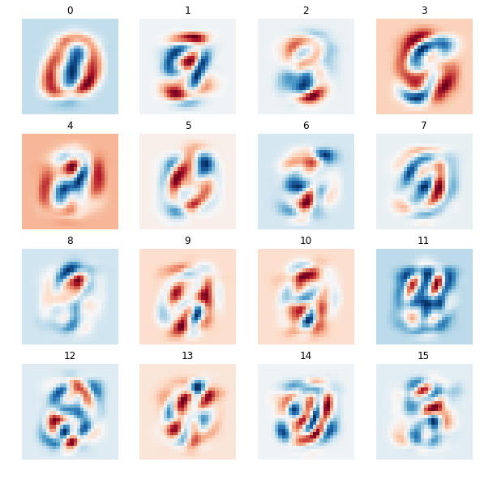

```python
ncomp = 16
_, dV, _ =  pca(D, ncomp)

plt.figure(figsize=(10, 10))
for k in range(ncomp):
    plt.subplot(4, 4, k+1)
    plt.imshow(np.reshape(dV[:, k], imgShape), cmap='RdBu')
    plt.axis('off')
    plt.title('{:d}'. format(k))
```

### Problem 4.4

Make a 10 by 4 array of subplots (with `figsize=(10, 25)`) that for each digit from 0 to 9 shows the first four principal components for images of that digit only. Display these components as images, as you did in the previous problem.

Show code and resulting plots. No titles are needed.

### Answer

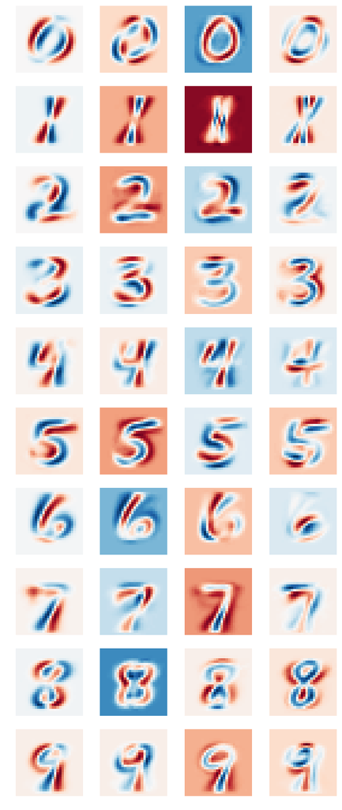

```python
ncomp = 4
plt.figure(figsize=(10, 25))
p = 1
for d in range(10):
    Dd = D[labels == d, :]
    _, ddV, _ = pca(Dd, 4)
    for k in range(ncomp):
        plt.subplot(10, 4, p)
        plt.imshow(np.reshape(ddV[:, k], imgShape), cmap='RdBu')
        plt.axis('off')
        p += 1
```

### Problem 4.5

Encoding a matrix $A$ by PCA amounts to projecting $A - \boldsymbol{\mu}$ onto the columns of $V$, that is, to computing the inner product (or "template match score") of $A - \boldsymbol{\mu}$ and $V$. Write a couple of brief paragraphs explaining what the pictures you made in problem 4.4 tell you about the distibution of the shapes of the various digits, perhaps referring to an example from your display for problem 4.4.

### Answer

Subtracting the mean $\boldsymbol{\mu}$ makes dark image values negative. The first column of $V$ is the image that captures most of the variation in the data set for a particular digit, so the digits vary mainly between the red part (largest negative inner product) and the blue part (largest positive inner product) of the picture in the first column of the display in problem 4.4. Other columns provide similar information for smaller modes of variation.